# ARIMA Model for Dow Jones Index

During exploratory data analysis (EDA) of Dow Jones Index, it was observed that the raw data is often non-stationary, exhibiting trends, seasonality, and other complex patterns that can make modeling and forecasting difficult. To address this issue, the data is often differentiated to achieve stationarity, which is a key assumption of the ARIMA model.

Differencing involves calculating the difference between each data point and the previous data point, which can help to remove trends and seasonality from the data. The goal is to create a new series of data that is stationary, meaning that the statistical properties of the data do not change over time.

#### Differentiated Time Series Plot

**Plot**

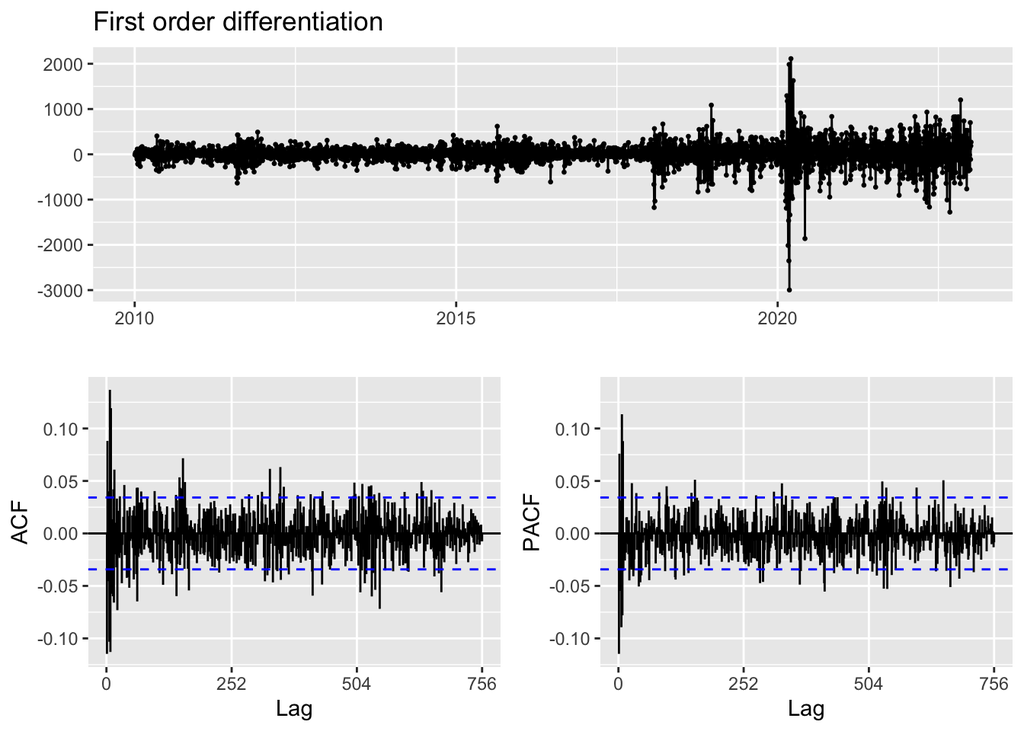

```r
#import the data
df <- read.csv("DATA/CLEANED DATA/dji_raw_data.csv")
#convert to time series data
myts<-ts(df$DJI.Adjusted,frequency=252,start=c(2010,1,4), end = c(2023,3,1))
#First order differentiation
df1 <- diff(myts)
# Plot
myts  %>% diff() %>% ggtsdisplay(main = "First order differentiation")
```

**ACF**

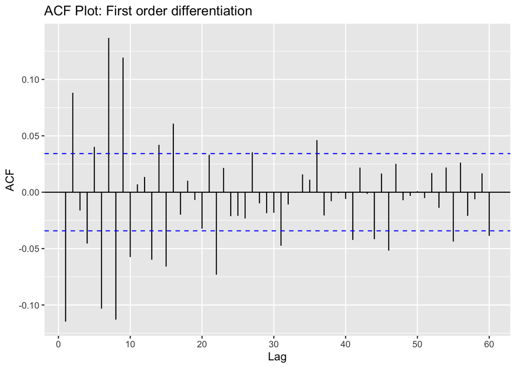

```r
#ACF plot
ggAcf(df1,60,main="ACF Plot: First order differentiation")
```

**PACF**

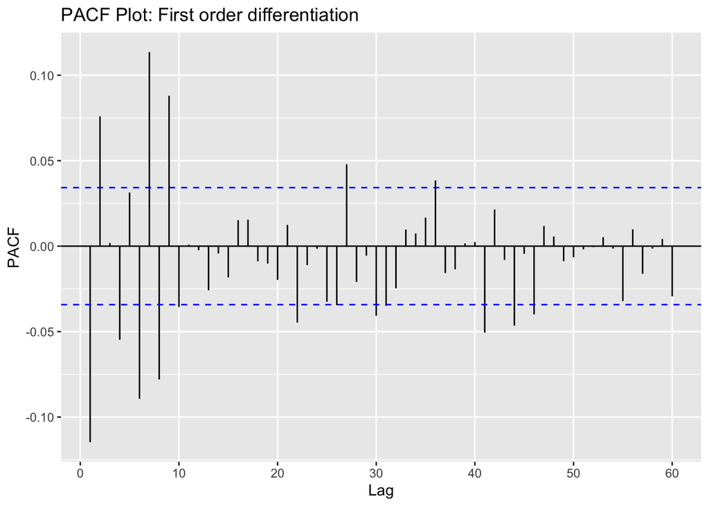

```r
ggPacf(df1,60,main="PACF Plot: First order differentiation")
```

**ADF Test**

```r
tseries::adf.test(df1)
```

```
    Augmented Dickey-Fuller Test

data:  df1
Dickey-Fuller = -15.31, Lag order = 14, p-value = 0.01
alternative hypothesis: stationary
```

After analyzing the ACF and PACF plots, it can be observed that most of the bar lines lie between the blue lines, indicating that the time series is stationary. This has been further confirmed through an Augmented Dickey-Fuller test as the p-value is less than 0.05. Once the data is stationary, the next step is to model it using ARIMA. The combination of ACF and PACF plots can help determine the appropriate values for p, d, and q in the ARIMA model. The order of differencing required to achieve stationarity gives the d value. The p value is determined by examining significant spikes at various lags in the PACF plot, while the q value is determined through significant spikes in the ACF plot. It is important to consider other methods such as grid search and information criteria to ensure the most appropriate model is selected.

Here the parameters are d = 1 p = 0,7 (PACF Plot) q = 0,7 (ACF Plot)